# Lab5_JaredMcMullen

Jared McMullen

10/20/2021

# Part 1

R itself is a free software for statistical computing with a strong community of members that have created tens of thousands of free packages. When installed on a computer it has all the computational power, but is hard to navigate. IDEs like RStudio are where private companies can make money through selling subscriptions to companies that plan to use Rstudio in their work, making R far easier to work with an draw insights from. While the R community allows the private companies to create these upgrades, it is important to them for the program to be open source and available to anyone that desires it.

2. 1.true 2.true 3.false 4.true 5.false 6.true

```r
a <-10
#Check to see
is.atomic(a)
```

```
## [1] TRUE
```

```r
is.array(a)
```

```
## [1] FALSE
```

```r
is.numeric(a)
```

```
## [1] TRUE
```

```r
is.integer(a)
```

```
## [1] FALSE
```

```r
length(a)
```

```
## [1] 1
```

```r
a+ c(1,2,3)
```

```
## [1] 11 12 13
```

```r
as.character(a)
```

```
## [1] "10"
```

```r
# Data frame Example
emp.data <- data.frame(
   emp_id = c (1:5),
   emp_name = c("Rick","Dan","Michelle","Ryan","Gary"),
   salary = c(623.3,515.2,611.0,729.0,843.25),

   start_date = as.Date(c("2012-01-01", "2013-09-23", "2014-11-15", "2014-05-11",
      "2015-03-27")),
   stringsAsFactors = FALSE
)
str(emp.data)
```

```
## 'data.frame':    5 obs. of  4 variables:
##  $ emp_id    : int  1 2 3 4 5
##  $ emp_name  : chr  "Rick" "Dan" "Michelle" "Ryan" ...
##  $ salary    : num  623 515 611 729 843
##  $ start_date: Date, format: "2012-01-01" "2013-09-23" ...
```

```r
#Vector example
my_vec <- c(1,2,3,4,5)
str(my_vec)
```

```
##  num [1:5] 1 2 3 4 5
```

```r
#List Example
my_list <-list("Red", "Green", c(21,32,11), TRUE, 51.23, 119.1)
str(my_list)
```

```
## List of 6
##  $ : chr "Red"
##  $ : chr "Green"
##  $ : num [1:3] 21 32 11
##  $ : logi TRUE
##  $ : num 51.2
##  $ : num 119
```

```r
#Matrices example
M <- matrix(c(3:14), nrow = 4, byrow = TRUE)
str(M)
```

```
##  int [1:4, 1:3] 3 6 9 12 4 7 10 13 5 8 ...
```

The object structure is a matrix.

```r
student_names <- c("Brad Pitt", "Kelsey yes", "John oliver", "okevin leary")
#str(my_vec)

str_extract(student_names, "^K")
```

```
## [1] NA  "K" NA  NA
```

```r
str_extract(student_names, "^K.*")
```

```
## [1] NA           "Kelsey yes" NA           NA
```

```r
str_extract(student_names, "^K[a-z]*")
```

```
## [1] NA       "Kelsey" NA       NA
```

```r
str_extract(student_names, "K[a-z]* ")
```

```
## [1] NA        "Kelsey " NA        NA
```

```r
str_subset(student_names, "^K")
```

```
## [1] "Kelsey yes"
```

```r
str_subset(student_names, "^K.*")
```

```
## [1] "Kelsey yes"
```

```r
str_subset(student_names, "^K[a-z]*")
```

```
## [1] "Kelsey yes"
```

```r
str_subset(student_names, "K[a-z]* ")
```

```
## [1] "Kelsey yes"
```

It would be options 5/6/7/8 that would return the full name.

```r
# How to check a term in the documentation = ?term - example <- ?rep

vectorify <- function(x) {

  if (length(x) == 1) {

    x <- rep(x, 10)

  } else {

    stop("x must be length 1")


  }

  return(x)

}
# Test 1
t<- c(2,1)
vectorify(t)
```

```
## Error in vectorify(t): x must be length 1
```

I believe option 5 (stop(“x must be length 1”)) would work the best as it makes the most sense considering the criteria for the input to be of length 1. It will stop the code before anything else is ran, which in this case would be the x value returned no matter if the criteria is met.

# Part Two: Write Functions

```r
get_footnotes <- function(vec) {
  list_vec = c()
  for (i in vec){
    myvec <- str_extract_all(i, "\\((.*?)\\)")
    list_vec <- append(list_vec, myvec)
  }
  return(list_vec)
}
#Test
vec <- c("1.01 - 1.02 (b)", "4.24 - 6.7 (c,b)", "1.5 (a) - 2.4 (d-f)")
get_footnotes(vec)
```

```
## [[1]]
## [1] "(b)"
##
## [[2]]
## [1] "(c,b)"
##
## [[3]]
## [1] "(a)"   "(d-f)"
```

```r
vec <- c("1.01 - 1.02 (b)", "4.24 - 6.7 (c,b)", "1.5 (a) - 2.4 (d-f)")

get_nums <- function(vec){
  vec <- str_replace_all(vec, "[()]", "")
  vec <- str_replace_all(vec, "\\,", "")
  vec <- str_replace_all(vec, "[:alpha:]", "")
  vec <- str_replace_all(vec, "\\-", "")
  vec <- str_trim(vec, side ="right")
  print(vec)
  df<- data.frame(
    First.Num = str_match(vec, "[^[:blank:]]+"),
    Last.Num = str_sub(vec, -4, -1 )
  )
  return(df)
}
get_nums(vec)
```

```
## [1] "1.01  1.02" "4.24  6.7"  "1.5   2.4"
```

```
##   First.Num Last.Num
## 1      1.01     1.02
## 2      4.24      6.7
## 3       1.5      2.4
```

# Part Three: Short Answer

```r
min_wage <- read_csv("/Users/jaredmcmullen/Desktop/GSE524/min_wage.csv")
head(min_wage,3)
```

```
## # A tibble: 3 × 9
##    Year State   Table_Data   Footnote High.Value Low.Value CPI.Average High.2018
##   <dbl> <chr>   <chr>        <chr>         <dbl>     <dbl>       <dbl>     <dbl>
## 1  1968 Alabama ...          <NA>           0        0            34.8      0
## 2  1968 Alaska  2.1          <NA>           2.1      2.1          34.8     15.1
## 3  1968 Arizona 18.72 - 26.… (b)            0.66     0.468        34.8      4.75
## # … with 1 more variable: Low.2018 <dbl>
```

```r
count(str_detect(min_wage$Footnote, "(b)"))
```

```
## Error in UseMethod("count"): no applicable method for 'count' applied to an object of class "logical"
```

```r
# Attempted this with two ways: One by a function that generates the Highest/Lowest min wage by year, and one by creating a data frame.



#Function approach:


# Highest/Lowest min_wage
find_max_min <- function(Years){
  min_wage <- na.omit(min_wage)
  min_wage <-
  min_wage %>%
    filter(Year == Years) %>%
    select(State, High.Value, Year) %>%
    arrange(desc(High.Value)) %>%
    arrange(desc(Year))
    print(head(min_wage, 1))
    print(tail(min_wage, 1))
}
#Test
find_max_min(2010)
```

```
## # A tibble: 1 × 3
##   State   High.Value  Year
##   <chr>        <dbl> <dbl>
## 1 Vermont       8.06  2010
## # A tibble: 1 × 3
##   State   High.Value  Year
##   <chr>        <dbl> <dbl>
## 1 Georgia       5.15  2010
```

```r
# Data frame approach


# Highest min wage by year
high_min_wage <-
  min_wage %>%
  na.omit(high_min_wage) %>%
  select(Year, High.Value, State) %>%
  group_by(Year) %>%
  slice_max(High.Value)

high_min_wage
```

```
## # A tibble: 50 × 3
## # Groups:   Year [50]
##     Year High.Value State
##    <dbl>      <dbl> <chr>
##  1  1968       1.65 California
##  2  1969       1.65 California
##  3  1970       1.65 California
##  4  1971       1.65 California
##  5  1972       1.65 California
##  6  1973       1.65 California
##  7  1974       1.65 California
##  8  1975       1.65 California
##  9  1976       1.7  Utah
## 10  1977       1.7  Utah
## # … with 40 more rows
```

```r
# Lowest Min wage by year
low_min_wage <-
  min_wage %>%
  na.omit(low_min_wage) %>%
  select(Year, High.Value, State) %>%
  group_by(Year) %>%
  slice_min(High.Value)

low_min_wage
```

```
## # A tibble: 73 × 3
## # Groups:   Year [50]
##     Year High.Value State
##    <dbl>      <dbl> <chr>
##  1  1968      0.156 Arkansas
##  2  1969      0.156 Arkansas
##  3  1970      0.66  Arizona
##  4  1971      0.66  Arizona
##  5  1972      0.66  Arizona
##  6  1973      0.66  Arizona
##  7  1974      0.66  Arizona
##  8  1975      0.66  Arizona
##  9  1976      1.25  Colorado
## 10  1977      1.25  Colorado
## # … with 63 more rows
```

```r
# Attempted this with two ways: One by a function that generates the largest change in wage by year, and one by creating a data frame.

# Function approach
min_wage <- read_csv("/Users/jaredmcmullen/Desktop/GSE524/min_wage.csv")
min_wage <- min_wage %>%
  mutate(
    difference = abs(High.Value - Low.Value)
  )
find_largest_change <- function(Years){
  min_wage <- na.omit(min_wage)
  min_wage <-
  min_wage %>%
    filter(Year == Years) %>%
    select(State, difference, Year) %>%
    arrange(desc(difference)) %>%
    arrange(desc(Year))
    print(head(min_wage, 1))
    print(tail(min_wage, 1))
}
# Test
find_largest_change(1968)
```

```
## # A tibble: 1 × 3
##   State difference  Year
##   <chr>      <dbl> <dbl>
## 1 Ohio         0.5  1968
## # A tibble: 1 × 3
##   State     difference  Year
##   <chr>          <dbl> <dbl>
## 1 Wisconsin          0  1968
```

```r
# Data frame approach
largest_difference <-
  min_wage %>%
  na.omit(largest_difference) %>%
  mutate(
    difference = abs(High.Value - Low.Value)
  ) %>%
  select(Year, difference, State) %>%
  group_by(Year) %>%
  slice_max(difference)

largest_difference
```

```
## # A tibble: 50 × 3
## # Groups:   Year [50]
##     Year difference State
##    <dbl>      <dbl> <chr>
##  1  1968       0.5  Ohio
##  2  1969       0.5  Ohio
##  3  1970       0.5  Ohio
##  4  1971       0.5  Ohio
##  5  1972       0.5  Ohio
##  6  1973       0.5  Ohio
##  7  1974       0.5  Ohio
##  8  1975       0.5  Ohio
##  9  1976       0.25 Colorado
## 10  1977       0.25 Colorado
## # … with 40 more rows
```

```r
min_wage <- read_csv("/Users/jaredmcmullen/Desktop/GSE524/min_wage.csv")
```

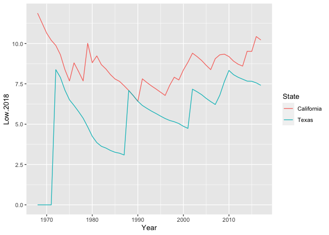

```r
target <- c("California", "Texas")
min_wage <- min_wage %>%
  filter(State %in% target)

ggplot() + geom_line(data = min_wage,  aes(x = Year, y = Low.2018, color = State))
```

```r
min_wage <- read_csv("/Users/jaredmcmullen/Desktop/GSE524/min_wage.csv")
min_wage <- min_wage %>%
  select(State, Year, High.2018) %>%
  group_by(State) %>%
  pivot_wider(names_from = State, values_from = High.2018)
min_wage
```

```
## # A tibble: 50 × 56
##     Year Alabama Alaska Arizona Arkansas California Colorado Connecticut
##    <dbl>   <dbl>  <dbl>   <dbl>    <dbl>      <dbl>    <dbl>       <dbl>
##  1  1968       0  15.1     4.75     1.12      11.9      9          10.1
##  2  1969       0  14.3     4.51     1.07      11.3      8.53        9.56
##  3  1970       0  13.5     4.26     7.09      10.6      8.06       10.3
##  4  1971       0  13.0     4.08     6.8       10.2      7.73        9.89
##  5  1972       0  12.6     3.95     7.19       9.88     7.49       11.1
##  6  1973       0  11.8     3.72     6.77       9.31     7.05       10.4
##  7  1974       0  10.7     3.35     6.09       8.38     6.35        9.39
##  8  1975       0   9.77    3.07     5.58       7.68     5.82        8.61
##  9  1976       0  12.3     0        8.36       8.8      5.5        10.2
## 10  1977       0  11.6     0        7.85       8.26     5.16        9.54
## # … with 40 more rows, and 48 more variables: Delaware <dbl>,
## #   District of Columbia <dbl>, Federal (FLSA) <dbl>, Florida <dbl>,
## #   Georgia <dbl>, Guam <dbl>, Hawaii <dbl>, Idaho <dbl>, Illinois <dbl>,
## #   Indiana <dbl>, Iowa <dbl>, Kansas <dbl>, Kentucky <dbl>, Louisiana <dbl>,
## #   Maine <dbl>, Maryland <dbl>, Massachusetts <dbl>, Michigan <dbl>,
## #   Minnesota <dbl>, Mississippi <dbl>, Missouri <dbl>, Montana <dbl>,
## #   Nebraska <dbl>, Nevada <dbl>, New Hampshire <dbl>, New Jersey <dbl>, …
```

# Part Four: Open-Ended Analysis

```r
min_wage <- read_csv("/Users/jaredmcmullen/Desktop/GSE524/min_wage.csv")
#Stateabb function

stateabb <- function(state) {
  return(state.abb[match(state, state.name)])

}
min_wage <- min_wage %>%
  mutate(stateABB = stateabb(State)) %>%
  select(-(Footnote)) %>%
  drop_na(min_wage$stateABB)
```

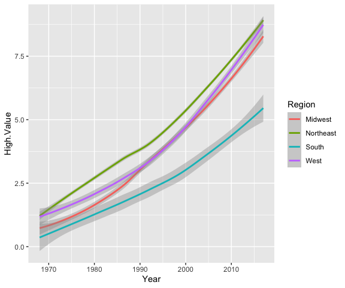

```r
min_wage <- min_wage %>%
  mutate(Region = case_when(stateABB == "CT" | stateABB == "ME" | stateABB == "MA" | stateABB == "NH" | stateABB == "RI" | stateABB == "VT" | stateABB == "NJ" | stateABB == "NY" | stateABB == "PA" ~ "Northeast",
                            stateABB == "IL" | stateABB == "IN" | stateABB == "MI" | stateABB == "OH" | stateABB == "WI" | stateABB == "IA" | stateABB == "KS" | stateABB == "MN" | stateABB == "MO" | stateABB == "NE" | stateABB == "ND" | stateABB == "SD" ~ "Midwest",
                            stateABB == "DE" | stateABB == "FL" | stateABB == "GA" | stateABB == "MD" | stateABB == "NC" | stateABB == "SC" | stateABB == "VA" | stateABB == "WV" | stateABB == "AL" | stateABB == "KY" | stateABB == "MS" | stateABB == "TN" | stateABB == "AR" | stateABB == "LA" | stateABB == "OK" | stateABB == "TX" ~ "South",
                            stateABB == "AZ" | stateABB == "CO" | stateABB == "ID" | stateABB == "MT" | stateABB == "NV" | stateABB == "NM" | stateABB == "UT" | stateABB == "WY" | stateABB == "AK" | stateABB == "CA" | stateABB == "HI" | stateABB == "OR" | stateABB == "WA" ~ "West"))


ggplot() + geom_smooth(data = min_wage,  aes(x = Year, y = High.Value, color = Region), size =1)
```

Based on how I was able to group by region, it is clear that the Midwest/Northeast/West have experienced the sharpest of inclines related to the minimum wage, while the the South is far behind others in terms of amount of growth rate. It is also clear that the North east has the highest overall minimum wage when compared to other regions, and has since the beginning of the minimum wage.

# One Page Write up

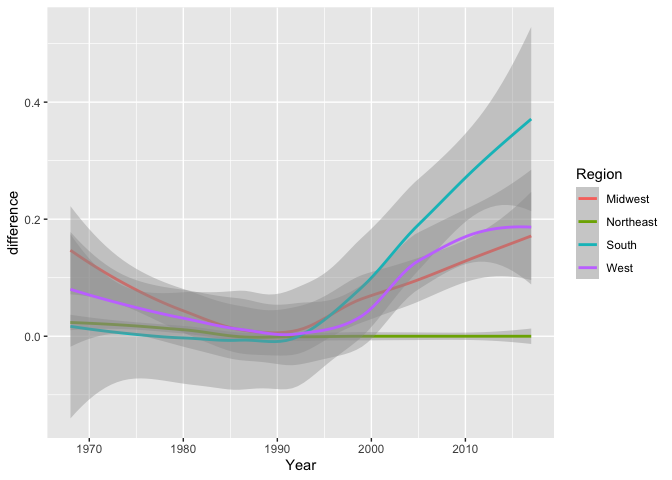

```r
min_wage<-
  min_wage %>%
  drop_na() %>%
  mutate(
    difference = abs(High.Value - Low.Value)
  )
ggplot() + geom_smooth(data = min_wage,  aes(x = Year, y= difference, color = Region), size =1)
```

When talking about minimum wage by region, it is important to talk about the difference between highest and lowest values of the minimum wage. This graph provides a strong visual of the difference in minimum wage by region throughout the past 53 years In general, a smaller difference is desired, meaning less of a disparity in minimum wage. We can see that the gap is growing in the Midwest, South, and the West. But the Northeast is experiencing a low disparity between states in the region. This can be interpreted in many ways. We know from the graph above that the Northeast is drastically increasing their minimum wage amounts. So by comparing the two graphs, we can see that the northeast is doing something right by lowering the disparity and raising the amount.

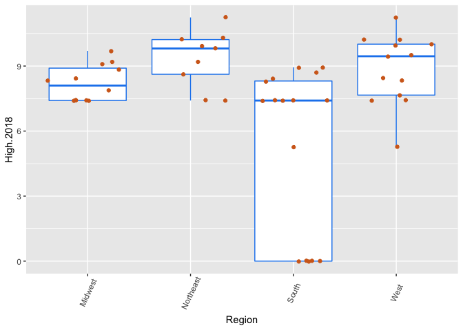

```r
min_wage <-
  min_wage %>%
  filter(Year == 2017)

library(ggthemes)
ggplot(data = min_wage, aes(Region, High.2018)) + theme(legend.position="none") + geom_boxplot(color = "dodgerblue2") + geom_jitter(color = "chocolate") + theme(axis.text.x = element_text(angle=65, vjust=0.6))
```

```r
# Summary statistic

mean <-mean(min_wage$High.Value)

test_stats <-
  min_wage %>%
  select(State, Year, High.Value) %>%
  group_by(State) %>%
  mutate(difference = High.Value - mean)
test_stats
```

```
## # A tibble: 50 × 4
## # Groups:   State [50]
##    State        Year High.Value difference
##    <chr>       <dbl>      <dbl>      <dbl>
##  1 Alabama      2017       0        -7.50
##  2 Alaska       2017       9.8       2.30
##  3 Arizona      2017      10         2.50
##  4 Arkansas     2017       8.5       0.997
##  5 California   2017      10         2.50
##  6 Colorado     2017       9.3       1.80
##  7 Connecticut  2017      10.1       2.60
##  8 Delaware     2017       8.25      0.747
##  9 Florida      2017       8.1       0.597
## 10 Georgia      2017       5.15     -2.35
## # … with 40 more rows
```

My summary statistic is the Difference between the High.value amount for a states highest High.value in 2017 and the mean high value score throughout the highest value scores (after the data is sliced). The States with the most positive difference are the ones in the upper half of the distribution and the ones with negative difference are in the lower half of the distribution.